# Tracking White-Tailed Deer Movement Patterns in the Duke Forest using Camera Traps

How does time of day and moon phase affect the movement of deer herds in the Duke Forest?

Sophie Moyer, Grace Randall, Ale Rios, Katie Tack

2023-12-12

## Content:

The data used in this project is of animal sightings on the trail cameras around the Duke forest and the spatial data of the Duke forest;it was collected as part of an ongoing project monitoring the white-tail deer population.

## Background:

```r
library(here)
here() #get working directory
```

```
## [1] "/Users/sophiemoyer/Documents/DukeForest-TackRiosMoyer"
```

[figure not shown]

```r
knitr::include_graphics(here("Images", "buck_day.jpg"))
```

## Setup & Data Wrangling:

### Importing Packages & Files

```r
#import packages
library(tidyverse)
library(lubridate)
library(viridis)
library(rvest);
library(dataRetrieval)
library(dplyr)
library(readr)
library(stringr)
library(sf);
library(mapview); mapviewOptions(fgb = FALSE)
library(RColorBrewer)
#install.packages("gt")
library(gt)
#install.packages("AICcmodavg")
library(AICcmodavg)

#custom theme to use for plots
custom.theme <- function() {
  theme_minimal() +
  theme(
    panel.background = element_rect(fill = "seashell"),
    panel.grid.major = element_line(colour = "bisque2", linetype = "dashed"),
    axis.line = element_line(colour = "black", size = 0.5),
    axis.text = element_text(size = 10, color = "salmon3", angle = 10),
    axis.title = element_text(size = 12, face = "bold", color = "salmon4"),
    plot.title = element_text(size = 16, color = "black", face = "bold", hjust = 0.5),
    plot.subtitle = element_text(size = 12, color = "gray", hjust = 0.5),
    legend.text = element_text(size = 10, color = "salmon3"),
    legend.title = element_text(size = 12, color = "salmon4", face = "bold"),
    legend.position = "right"
  )
}
```

```r
#read excel file
trailcam_csv <- read.csv(here("Data", "Raw", "sequences.csv"))
moon_phases_csv <- read.csv(here("Data", "Raw", "moon_phases.csv"))
```

### Creating Date & Time Objects

```r
#date as objects
trailcam_csv$start_time <- ymd_hms(trailcam_csv$start_time)
trailcam_csv$end_time <- ymd_hms(trailcam_csv$end_time)
moon_phases_csv$start_date <- as.Date(moon_phases_csv$start_date)
```

```r
#separate date and time
trailcam_csv$start_date <- as.Date(trailcam_csv$start_time)
trailcam_csv$start_time <- format(trailcam_csv$start_time, "%H")
trailcam_csv$month <- month(as.Date(trailcam_csv$start_date))
trailcam_csv$month_name <- month.name[trailcam_csv$month]

trailcam_csv$end_date <- as.Date(trailcam_csv$end_time)
trailcam_csv$end_time <- format(trailcam_csv$end_time, "%H")
```

### Filtering Joining & Categorizing

```r
#filter for white- tailed deer, select relevant columns, and isolate trail camera id number.
deer_data <- trailcam_csv %>%
  filter(common_name == "White-tailed Deer") %>%
  select(common_name, deployment_id, start_date, start_time, group_size, month, month_name, end_time) %>%
  mutate(cam_id = as.numeric(str_extract(deployment_id, "\\d+")),
                             division = str_extract(deployment_id, "\\((.*?)\\)"))
#cam_id refers to the camera id number
#mutate(cam_id = as.numeric(str_extract(deployment_id, "\\d+"))) taken from stackoverflow

#read file with trail camera coordinates (delivered as a .xlsx and converted to a .csv)
cam_coords <- read.csv(here("Data", "Raw", "camera_coords.csv"))

#Select id number and coordinates
cam_coordinates <- cam_coords %>%
  mutate(cam_id = as.numeric(str_extract(deployment_id, "\\d+")))
```

```r
#join deer data with trail camera coordinate data to find where cameras are, and clean up data
deer_cam_data <- left_join(deer_data, cam_coordinates, by = "cam_id") %>%
  select(common_name, start_date, start_time, group_size, cam_id, division, longitude, latitude, month, month_name)
deer_cam_data <- left_join(deer_cam_data, moon_phases_csv, by = "start_date")

#categorize hours into groups
deer_cam_data$start_time <- as.numeric(deer_cam_data$start_time)
categorize_time <- function(hour) {
  ifelse(hour >= 6 & hour < 12, "Morning",
         ifelse(hour >= 12 & hour < 20, "Afternoon", "Evening"))
}
deer_cam_data$time_category <- cut(deer_cam_data$start_time,
                                   breaks = c(-Inf, 5.99, 11.99, 19.99, Inf),
                                   labels = c("Evening", "Morning", "Afternoon", "Evening"),
                                   right = FALSE)

categorize_moon_phase <- function(phase) {
  phase_lower <- tolower(phase)
  if (grepl("full", phase_lower) || grepl("gibbous", phase_lower)) {
    return("FullAndGibbous")
  } else if (grepl("new", phase_lower) || grepl("crescent", phase_lower)) {
    return("NewAndCrescent")
  } else {
    return("QuarterMoon")
  }
}

deer_cam_data$moon_type <- sapply(deer_cam_data$moon_phase, categorize_moon_phase)

#read Duke forest boundary shapefile into project
#here("Duke University/Documents/EDE_Fall2023/DukeForest-TackRiosMoyer/duke-forest-spatial-data/duke-forest-spatial-data/Boundary")
#forest_sf <- st_read("Duke_Forest_Boundary_Mar2022.shp")
#mapview(forest_sf)

#adding a new column - categorical time of day
deer_data <- deer_data %>% mutate(
    TOD = case_when(
      start_time %in% c(20, 21, 22, 23, "00", "01", "02", "03") ~ 'night ',
      start_time %in% c("04", "05", "06", "07", "08", "09", 10, 11) ~ 'morning',
      start_time %in% c(12, 13, 14, 15, 16, 17, 18, 19) ~ 'day',
      TRUE ~ NA_character_
    )
  )
#categorical variable for moon phase
deer_data <- inner_join(deer_data, moon_phases_csv, by = "start_date")
```

### Coverting Spatial Data to Dataframe

```r
#convert coordinates to a spatial dataframe
#deer_cam_data_sf <- deer_cam_data_sf %>% st_as_sf(coords = c("Longtitude","Latitude"), crs=4326)
```

## Statistical Tests & Machine Learning:

### Understanding the data

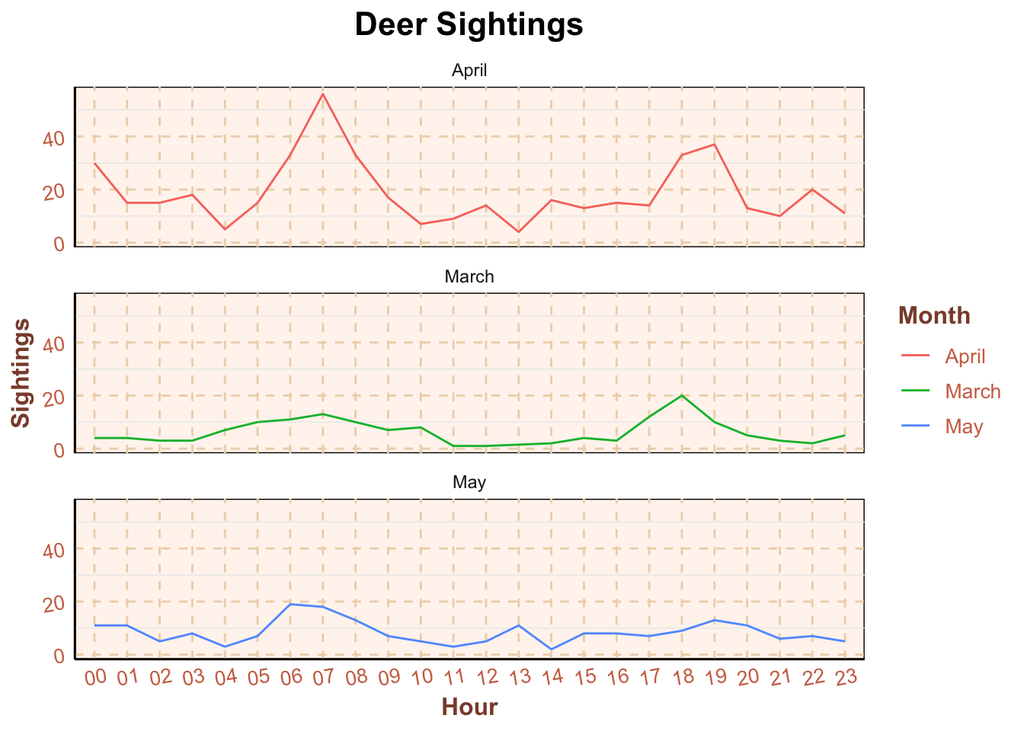

```r
deer_data <- deer_data %>%
  arrange(month, start_time)

# Calculate sum of sightings by month and hour
deer_hours <- deer_data %>%
  group_by(month, start_time, month_name) %>%
  mutate(sightings = 1, .groups = 'drop') %>%
  summarise(sightings = sum(sightings), .groups = 'drop')

# Create a line plot using ggplot2
ggplot(deer_hours, aes(x = start_time, y = sightings, group = month, color = as.factor(month_name))) +
  geom_line() +
  labs(title = "Deer Sightings", x = "Hour",  y = "Sightings") +
  scale_color_discrete(name = "Month") + custom.theme() + facet_wrap(~ month_name, ncol = 1)
```

Looking at this plot, we can see there is an obvious spike of deer sightings around 6am and 7pm in the month of April, and slight spikes around those times for March and May. To further understand the relationship between deer sightings and time of day, we will perform several statistical tests.

### ANVOA Tests

```r
#testing hypothesis one - time of day has no effect on deer observations
time.one.way <- aov(group_size ~ TOD, data = deer_data)
summary(time.one.way)
```

```
##              Df Sum Sq Mean Sq F value Pr(>F)
## TOD           2    3.7  1.8634   3.929   0.02 *
## Residuals   800  379.4  0.4742
## ---
## Signif. codes:  0 '***' 0.001 '**' 0.01 '*' 0.05 '.' 0.1 ' ' 1
```

```r
#TOD is significant

#testing hypothesis three - moon phase has no impact on deer observations
moon.one.way <- aov(group_size ~ moon_phase, data = deer_data)
summary(moon.one.way)
```

```
##              Df Sum Sq Mean Sq F value Pr(>F)
## moon_phase    7    3.6  0.5197   1.089  0.368
## Residuals   795  379.5  0.4773
```

```r
#again, small F-value and large p-value so there is little to suggest that the moon phase influences deer observations

#moon and time test
moon.and.time <- aov(group_size ~ TOD + moon_phase, data = deer_data)
summary(moon.and.time)
```

```
##              Df Sum Sq Mean Sq F value Pr(>F)
## TOD           2    3.7  1.8634   3.935 0.0199 *
## moon_phase    7    3.9  0.5583   1.179 0.3121
## Residuals   793  375.5  0.4735
## ---
## Signif. codes:  0 '***' 0.001 '**' 0.01 '*' 0.05 '.' 0.1 ' ' 1
```

```r
#no effect?

#interaction test
moon.time <- aov(group_size ~ TOD*moon_phase, data = deer_data)
summary(moon.time)
```

```
##                 Df Sum Sq Mean Sq F value Pr(>F)
## TOD              2    3.7  1.8634   3.889 0.0209 *
## moon_phase       7    3.9  0.5583   1.165 0.3203
## TOD:moon_phase  14    2.3  0.1614   0.337 0.9891
## Residuals      779  373.2  0.4791
## ---
## Signif. codes:  0 '***' 0.001 '**' 0.01 '*' 0.05 '.' 0.1 ' ' 1
```

```r
#The results indicate a statistically significant main effect of TOD on the response variable. However, there is no significant main effect of moon_phase and no significant interaction effect between TOD and moon_phase.

#maybe the division locations are adding a block?
moon.time.block <- aov(group_size ~ TOD*moon_phase + division, data = deer_data)
summary(moon.time.block)
```

```
##                 Df Sum Sq Mean Sq F value Pr(>F)
## TOD              2    3.7  1.8634   3.882  0.021 *
## moon_phase       7    3.9  0.5583   1.163  0.322
## division         2    0.2  0.0910   0.190  0.827
## TOD:moon_phase  14    2.3  0.1631   0.340  0.989
## Residuals      777  373.0  0.4801
## ---
## Signif. codes:  0 '***' 0.001 '**' 0.01 '*' 0.05 '.' 0.1 ' ' 1
```

```r
#low sum of squares and high p means the block is adding little information to our analysis - not relevant
```

### The one-way ANOVA (Analysis of Variance) results suggest that there is a statistically significant difference among the means of the groups defined by the variable `TOD` (Time of Day). Here’s how to interpret the output:

1. **Df (Degrees of Freedom):** This indicates the degrees of freedom associated with the groups and residuals.
   - For `TOD`: 2 degrees of freedom.
   - For `Residuals`: 800 degrees of freedom.
2. **Sum Sq (Sum of Squares):** This is a measure of the total variability in the data.
   - For `TOD`: 3.7
   - For `Residuals`: 379.4
3. **Mean Sq (Mean Sum of Squares):** This is obtained by dividing the Sum of Squares by its corresponding degrees of freedom.
   - For `TOD`: 1.8634
   - For `Residuals`: 0.4742
4. **F value (F-statistic):** This is the ratio of the variance among group means to the variance within the groups. It is calculated as the Mean Square for `TOD` divided by the Mean Square for `Residuals`.
   - In this case, the F value is 3.929.
5. **Pr(>F) (p-value):** This is the probability of obtaining an F-statistic as extreme as, or more extreme than, the one observed in the data, assuming the null hypothesis is true.
   - In this case, the p-value is 0.02, which is less than the commonly used significance level of 0.05.

**Interpretation:** The p-value (Pr(>F)) is less than 0.05, indicating that there is evidence to reject the null hypothesis. Therefore, there is a statistically significant difference in means among the groups defined by `TOD`. However, the specific interpretation of which groups are different would require further post-hoc tests or examination of the group means.

It’s also worth noting that the effect size and the context of your study should be considered when interpreting the practical significance of the results.